# Spotify

Consulting Project

Week 9

## Background

My friend [Freddy Velazquez](https://www.instagram.com/freddyv98/) is in need of help figuring out what makes music more popular. [Canillas (Freddy)](https://open.spotify.com/artist/40rHTqqZNlzw3TrcVXlSUI) has 26 monthly listeners, and is trying to get more listeners. This would help since his new album comes out soon. I will be using a Linear Regression model to figure out what makes music popular. The [spotify data](https://raw.githubusercontent.com/byui-cse/cse450-course/master/data/spotify/data.csv) I am using is from 2015 to 2020.

## Data Analytics

### Basic Stats

#### Summary of Popularity

```r
pandary(spotify$popularity)
```

| Min. | 1st Qu. | Median | Mean | 3rd Qu. | Max. |
| --- | --- | --- | --- | --- | --- |
| 0 | 60 | 64.5 | 64.36 | 70 | 100 |

#### Fav Stats of Popularity based on Year

```r
pander(favstats(popularity ~ year, data = spotify)[,-10])
```

| year | min | Q1 | median | Q3 | max | mean | sd | n |
| --- | --- | --- | --- | --- | --- | --- | --- | --- |
| 2015 | 48 | 54 | 59 | 64 | 91 | 59.55 | 6.636 | 1931 |
| 2016 | 50 | 57 | 61 | 65 | 92 | 61.37 | 6.329 | 1969 |
| 2017 | 54 | 60 | 64 | 68 | 87 | 64.86 | 6.059 | 2000 |
| 2018 | 56 | 62 | 66 | 71 | 92 | 67.28 | 6.177 | 2000 |
| 2019 | 58 | 65 | 68 | 74 | 95 | 69.66 | 6.538 | 2000 |
| 2020 | 0 | 63 | 68 | 73 | 100 | 63.11 | 21.28 | 1756 |

### Linear Regression

```r
simple <- function(x){

  # Preform Regression

  mylm <- lm(popularity ~ x, data = spotify)

  # Diagnostic

  par(mfrow=c(1,3))
  plot(mylm, which=1:2)
  plot(mylm$residuals)

  # Create Plot

  myplot <- ggplot(spotify, aes(y = popularity, x = x)) +
    geom_point(color = "red") +
    geom_smooth(method = "lm", se=FALSE, color = "black") +
    theme_bw()

  # Create List and Return List

  mylist <- list("lm" = mylm, "plot" = myplot)
  return(mylist)
}
```

#### Danceability

```r
lm_danceability <- simple(spotify$danceability)
```

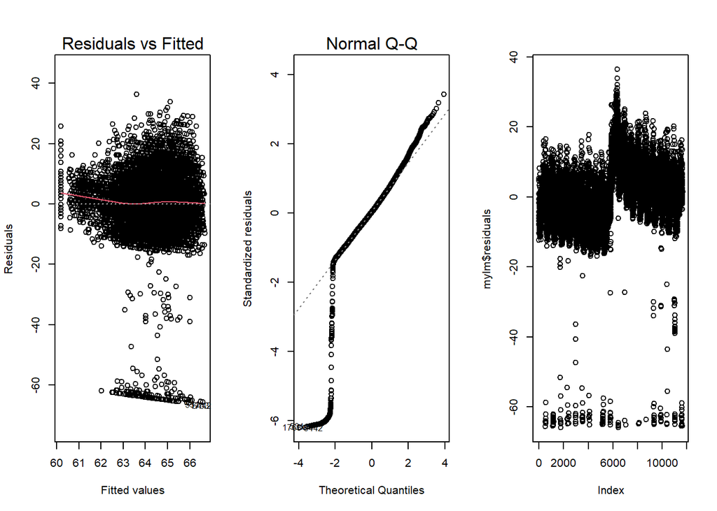

```r
pandary(lm_danceability$lm)
```

|  | Estimate | Std. Error | t value | Pr(>\|t\|) |
| --- | --- | --- | --- | --- |
| **(Intercept)** | 60.19 | 0.367 | 164 | 0 |
| **x** | 6.623 | 0.5609 | 11.81 | 5.413e-32 |

Fitting linear model: popularity ~ x

| Observations | Residual Std. Error | $R^2$ | Adjusted $R^2$ |
| --- | --- | --- | --- |
| 11656 | 10.63 | 0.01182 | 0.01174 |

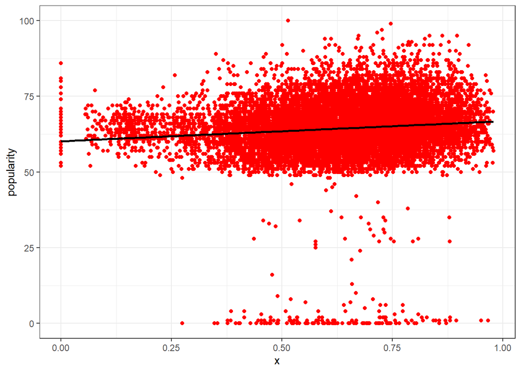

```r
lm_danceability$plot
```

#### Duration

```r
lm_duration <- simple(spotify$duration_ms)
```

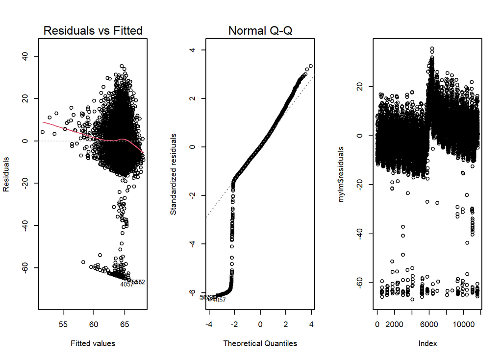

```r
pandary(lm_duration$lm)
```

|  | Estimate | Std. Error | t value | Pr(>\|t\|) |
| --- | --- | --- | --- | --- |
| **(Intercept)** | 68.67 | 0.3878 | 177.1 | 0 |
| **x** | -2.066e-05 | 1.8e-06 | -11.47 | 2.612e-30 |

Fitting linear model: popularity ~ x

| Observations | Residual Std. Error | $R^2$ | Adjusted $R^2$ |
| --- | --- | --- | --- |
| 11656 | 10.63 | 0.01117 | 0.01108 |

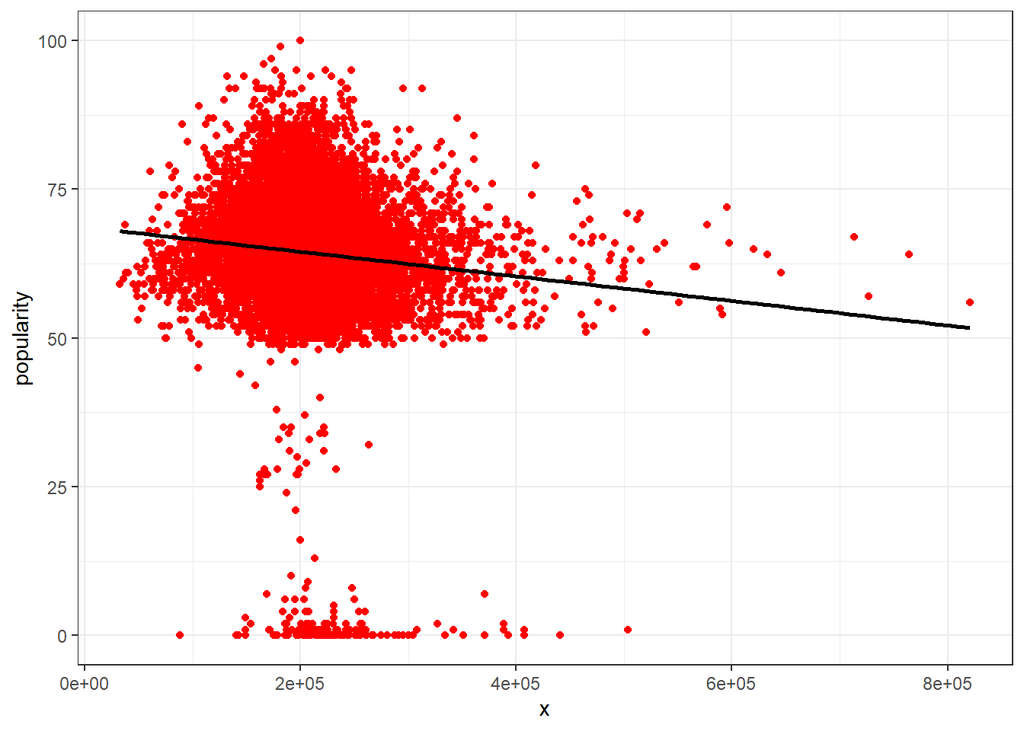

```r
lm_duration$plot
```

#### Energy

```r
lm_energy <- simple(spotify$energy)
```

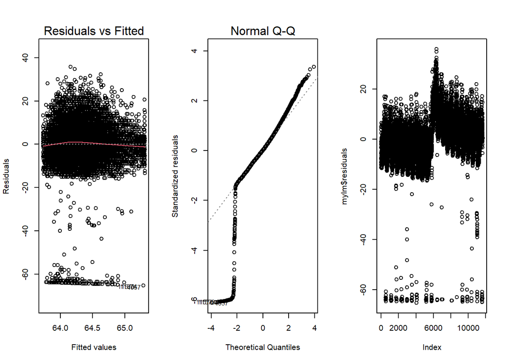

```r
pandary(lm_energy$lm)
```

|  | Estimate | Std. Error | t value | Pr(>\|t\|) |
| --- | --- | --- | --- | --- |
| **(Intercept)** | 65.31 | 0.2979 | 219.2 | 0 |
| **x** | -1.572 | 0.4693 | -3.35 | 0.0008116 |

Fitting linear model: popularity ~ x

| Observations | Residual Std. Error | $R^2$ | Adjusted $R^2$ |
| --- | --- | --- | --- |
| 11656 | 10.69 | 0.0009619 | 0.0008761 |

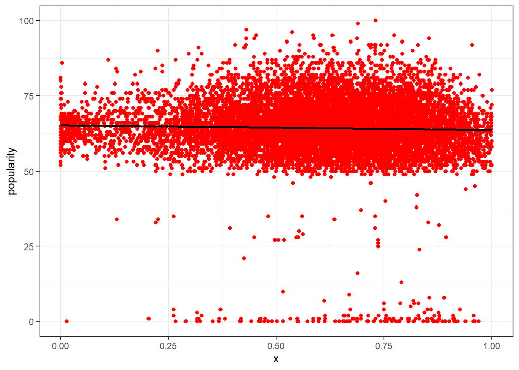

```r
lm_energy$plot
```

#### Liveness

```r
lm_liveness <- simple(spotify$liveness)
```

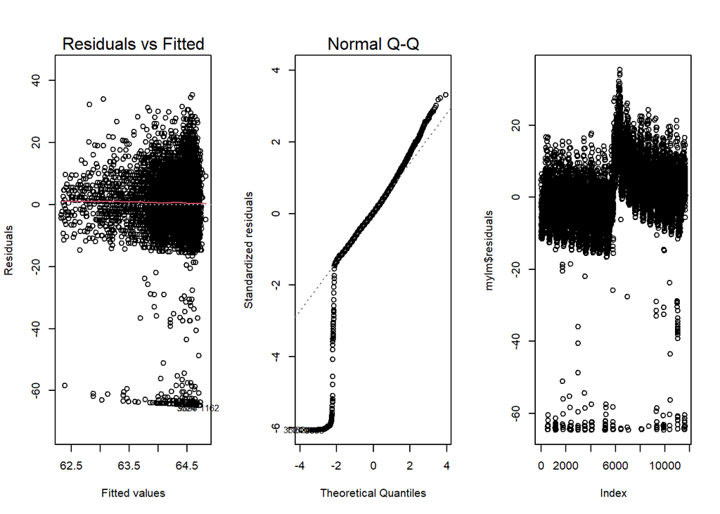

```r
pandary(lm_liveness$lm)
```

|  | Estimate | Std. Error | t value | Pr(>\|t\|) |
| --- | --- | --- | --- | --- |
| **(Intercept)** | 64.82 | 0.1591 | 407.3 | 0 |
| **x** | -2.534 | 0.6936 | -3.653 | 0.0002599 |

Fitting linear model: popularity ~ x

| Observations | Residual Std. Error | $R^2$ | Adjusted $R^2$ |
| --- | --- | --- | --- |
| 11656 | 10.69 | 0.001144 | 0.001058 |

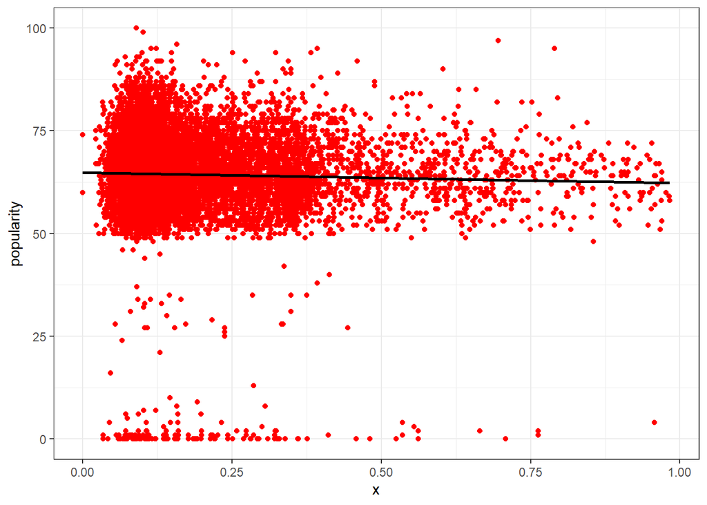

```r
lm_liveness$plot
```

#### Loudness

```r
lm_loudness <- simple(spotify$loudness)
```

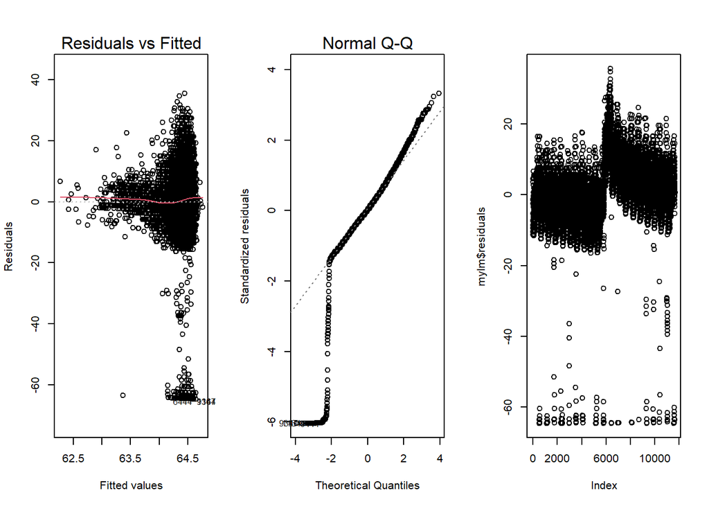

```r
pandary(lm_loudness$lm)
```

|  | Estimate | Std. Error | t value | Pr(>\|t\|) |
| --- | --- | --- | --- | --- |
| **(Intercept)** | 64.71 | 0.1794 | 360.6 | 0 |
| **x** | 0.04487 | 0.01949 | 2.302 | 0.02133 |

Fitting linear model: popularity ~ x

| Observations | Residual Std. Error | $R^2$ | Adjusted $R^2$ |
| --- | --- | --- | --- |
| 11656 | 10.69 | 0.0004547 | 0.0003689 |

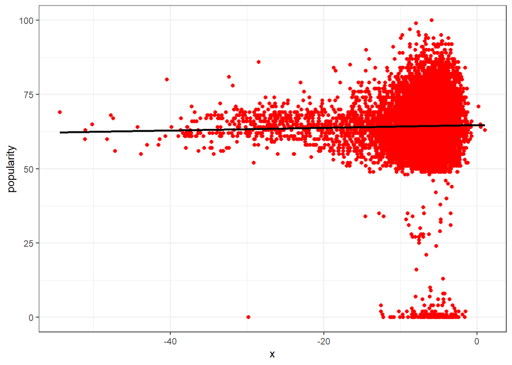

```r
lm_loudness$plot
```

#### Tempo

```r
lm_tempo <- simple(spotify$tempo)
```

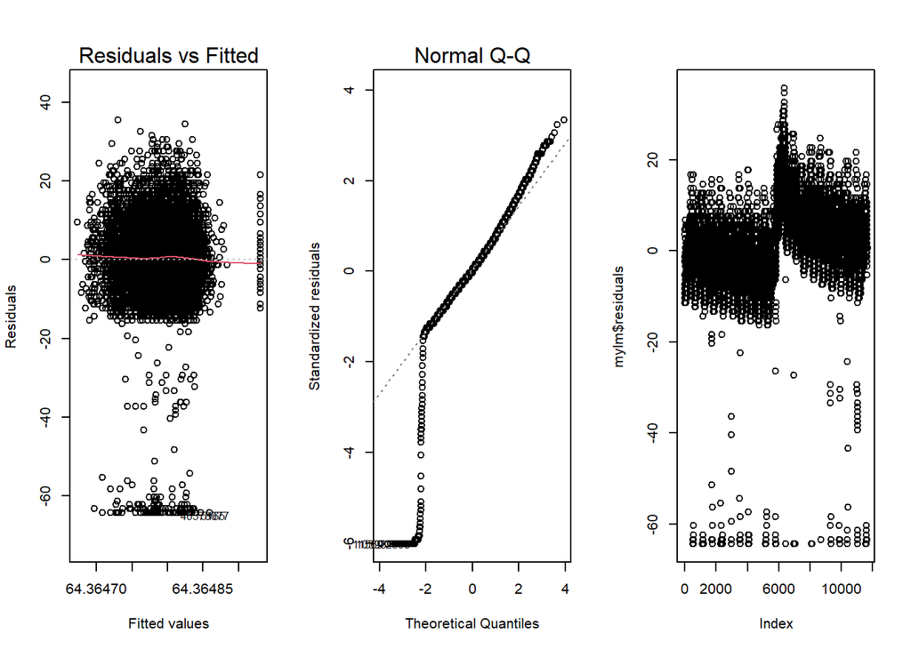

```r
pandary(lm_tempo$lm)
```

|  | Estimate | Std. Error | t value | Pr(>\|t\|) |
| --- | --- | --- | --- | --- |
| **(Intercept)** | 64.36 | 0.3916 | 164.3 | 0 |
| **x** | -1.17e-06 | 0.003169 | -0.0003692 | 0.9997 |

Fitting linear model: popularity ~ x

| Observations | Residual Std. Error | $R^2$ | Adjusted $R^2$ |
| --- | --- | --- | --- |
| 11656 | 10.69 | 1.17e-11 | -8.581e-05 |

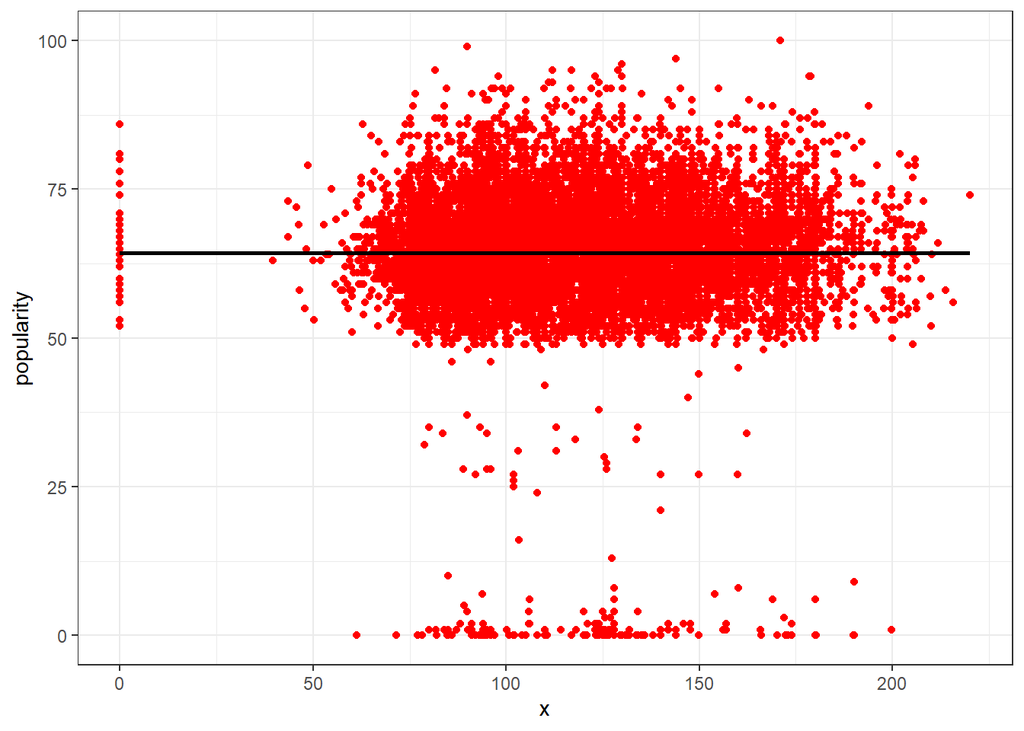

```r
lm_tempo$plot
```

#### Year

```r
lm_year <- simple(spotify$year)
```

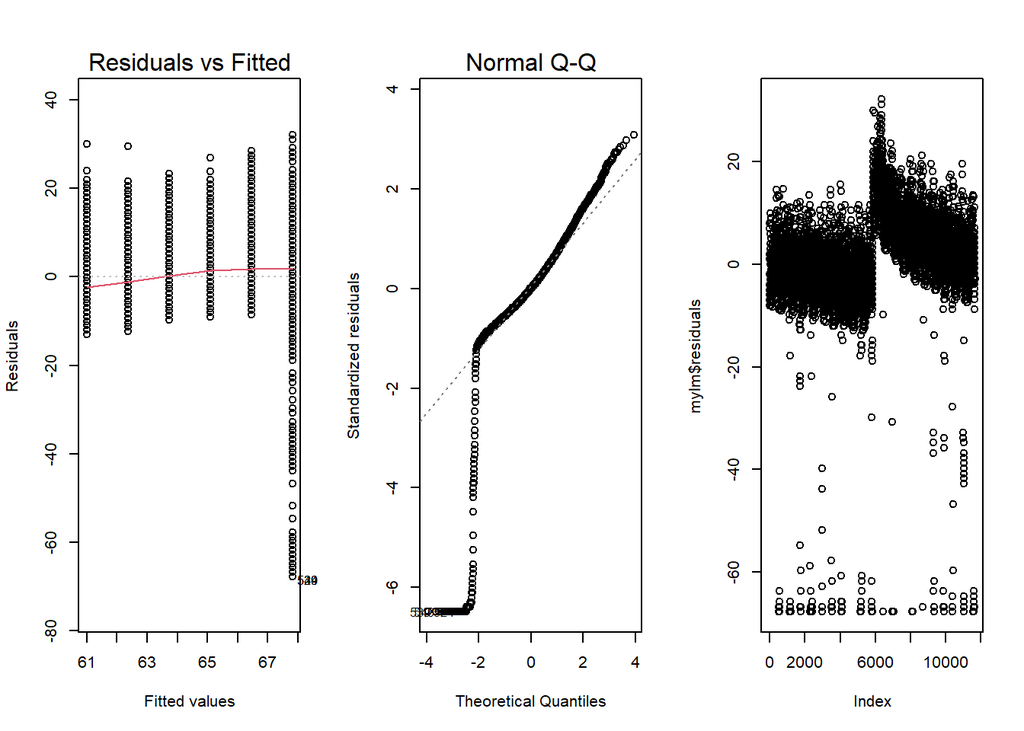

```r
pandary(lm_year$lm)
```

|  | Estimate | Std. Error | t value | Pr(>\|t\|) |
| --- | --- | --- | --- | --- |
| **(Intercept)** | -2683 | 116.1 | -23.11 | 1.31e-115 |
| **x** | 1.362 | 0.05753 | 23.67 | 5.323e-121 |

Fitting linear model: popularity ~ x

| Observations | Residual Std. Error | $R^2$ | Adjusted $R^2$ |
| --- | --- | --- | --- |
| 11656 | 10.44 | 0.04586 | 0.04578 |

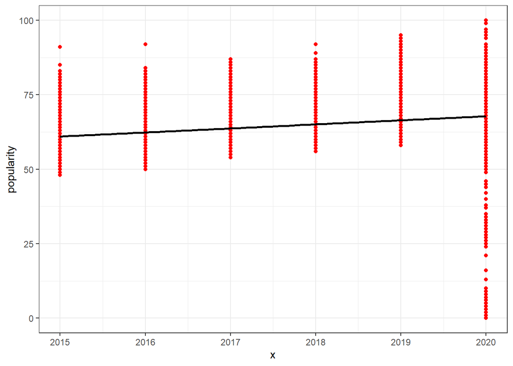

```r
lm_year$plot
```

## Interpretation

First I would like to mention that as years go on new songs increase in popularity, which is good for you. Next lets see what each regression tells us.

- Danceability - Increasing popularity with increasing Danceability - Slope = 6.623
- Duration - Decreasing popularity with increasing duration - Slope = -2.066e-05
- Energy - Decreasing popularity with increasing energy - Slope = -1.572
- Liveness - Decreasing popularity with increasing liveness - Slope = -2.534
- Loudness - Increasing popularity with increasing loudness - Slope = 0.04487
- Tempo - Decreasing popularity with increasing tempo - Slope = -1.17e-06
- Year - Increasing popularity with increasing year - Slope = 1.362

So basically we it is danceable and loud then it would have a high popularity.

Freddy your music fits both being danceable and loud so so as lonas it’s not super long that your music would be popular.